# Hedonic Home Price Prediction for Boulder, CO

### 4.4 Predicted sale price as function of observed price

Figure 6.1 plotted the predicted sale price as function of observed price. By comparing the gaps between the prediction (green line) and the perfect prediction (orange line), our predicted prices were close for majority. However, as prices increased, more errors spread out. By comparing the baseline regression and the neighbourhoods effects model in Figure 6.2, we noticed that the previous baseline regression was already close to the prefect prediction, but neighbourhoods effect even fits better slightly.

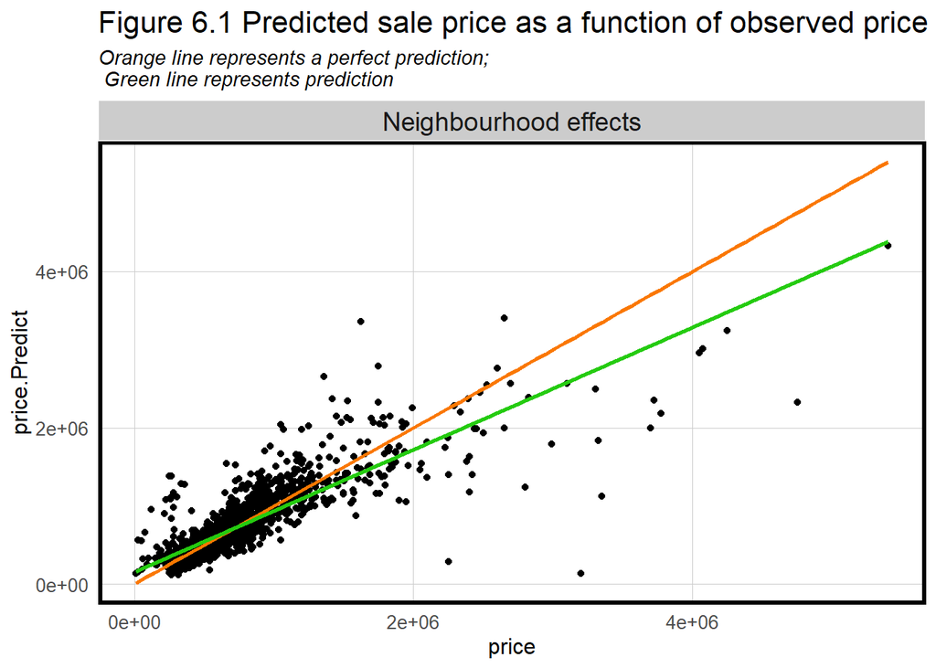

```r
housing.test.nhood1<-housing.test.nhood%>%
  filter(price<5500000, price.Predict<5500000&price.Predict>0)

ggplot(housing.test.nhood1,aes(price, price.Predict)) +
  geom_point() +
  stat_smooth(data=housing.test.nhood1,aes(price, price),
              method = "lm", se = FALSE, size = 1, colour="#FA7800") +
  stat_smooth(data=housing.test.nhood1,aes(price,price.Predict),
              method = "lm", se = FALSE, size = 1, colour="#25CB10") +
  facet_wrap(~Regression) +
  labs(title="Figure 6.1 Predicted sale price as a function of observed price",
       subtitle="Orange line represents a perfect prediction;
 Green line represents prediction") +
  plotTheme()
```

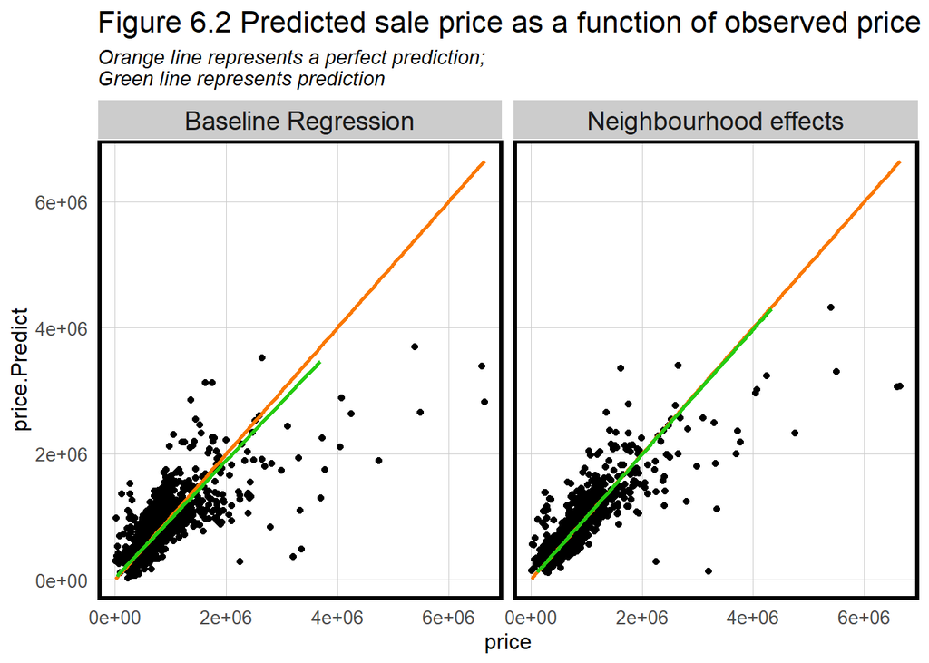

```r
comparison %>%
  dplyr::select(price.Predict, price, Regression) %>%
  ggplot(aes(price, price.Predict)) +
  geom_point() +
  stat_smooth(aes(price, price),
              method = "lm", se = FALSE, size = 1, colour="#FA7800") +
  stat_smooth(aes(price.Predict, price),
              method = "lm", se = FALSE, size = 1, colour="#25CB10") +
  facet_wrap(~Regression) +
  labs(title="Figure 6.2 Predicted sale price as a function of observed price in comparison",
       subtitle="Orange line represents a perfect prediction;
Green line represents prediction") +
  plotTheme()
```